# DATASCI 350 - Data Science Computing

Lecture 22 - Scaling Data Analysis in Practice

Danilo Freire

danilo.freire@emory.edu

Department of Data and Decision Sciences  
Emory University

# Hello again! 😊 How’s everything?

# Brief recap 📚

## Parallel computing fundamentals

### Where lecture 21 left us

- Last class we covered the concepts of parallel and scalable computing:
  - `map`, embarrassingly parallel problems, and `joblib` / `concurrent.futures`
  - Big O: parallelism cuts the constant while the complexity class stays the same
  - [Amdahl’s law](https://en.wikipedia.org/wiki/Amdahl%27s_law): speed-up is capped by the serial share, so measure before scaling
  - [The GIL](https://en.wikipedia.org/wiki/Global_interpreter_lock): threads help for I/O, processes for CPU, and C/Rust libraries sidestep it entirely
  - Dask basics: lazy arrays and DataFrames for bigger-than-RAM data
- We ended with a promise: some engines parallelise for you, with no cluster to manage
- Today is the practice session: we decide which tool you actually reach for
- We will meet [Polars](https://pola.rs/) and [DuckDB](https://duckdb.org/), then race all four engines on the WDI panel we built in Module 06

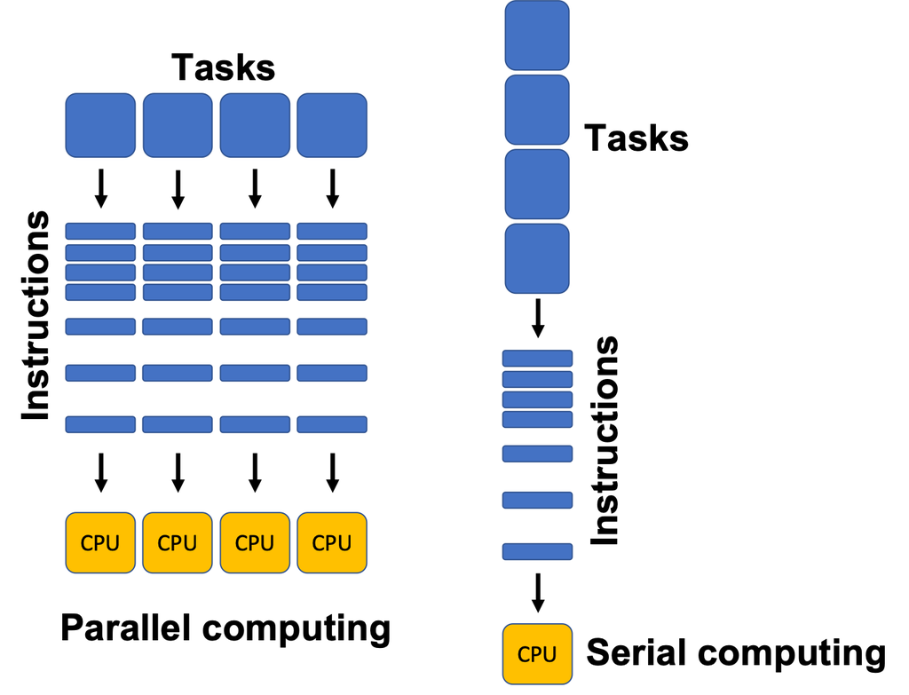

# Today’s agenda

## Lecture outline

### What we will cover today

- Set up [local Dask Clusters](https://docs.dask.org/en/stable/deploying-python.html) with workers, schedulers, and the dashboard
- The [single-machine renaissance](https://duckdblabs.github.io/db-benchmark/): why most “big data” now fits on one laptop
- [Polars](https://pola.rs/): a fast DataFrame library with lazy evaluation and streaming
- [DuckDB](https://duckdb.org/): SQL as an out-of-core scaling tool
- [The benchmark](https://raw.githubusercontent.com/danilofreire/datasci350/main/lectures/lecture-22/data/benchmark_results.csv): pandas vs Polars vs DuckDB vs Dask on 200 million rows
- Which tool when: a decision framework, plus a short word on [GPUs](https://developer.nvidia.com/topics/ai/data-science/cuda-x-for-data-science)

[figure not shown]

Every output on these slides comes from a real run on my laptop. The benchmark was measured once and saved to [`data/benchmark_results.csv`](https://raw.githubusercontent.com/danilofreire/datasci350/main/lectures/lecture-22/data/benchmark_results.csv)

# Dask Clients and Clusters 🌐

## What is a Dask Cluster?

### Workers and schedulers

- A [Dask Cluster](https://docs.dask.org/en/stable/deploying.html) is a group of computational engines (cores, GPUs, servers, etc.) that work together to solve a problem
- Workers provide two functions:
  - Compute tasks as directed by the scheduler. The scheduler is the brain of the cluster
  - Store and serve computed results to other workers or clients
- Workers are the reason why lazy evaluation speeds up computations
- Here is a simple example:

```markdown
Scheduler -> Eve: Compute a <- multiply(3, 5)!
Eve -> Scheduler: I've computed a and am holding on to it!
Scheduler -> Frank: Compute b <- add(a, 7)!
Frank: You will need a. Eve has a.
Frank -> Eve: Please send me a.
Eve -> Frank: Sure. a is 15!
Frank -> Scheduler: I've computed b and am holding on to it!
```

## What is a Dask Cluster?

### How the scheduler assigns work

- How do workers know what to do?
  - The scheduler assigns tasks to workers based on their availability
  - Workers can be on the same machine or on different machines
  - Workers can be CPUs or GPUs
- These processes can automatically restart and scale up without any intervention from the user
- The optimal number of workers depends on data size and computation complexity
- The default configuration is usually enough
- In an adaptive cluster, you set the minimum and maximum number of workers
- The cluster adds and removes workers as the work demands
- Dask also provides a dashboard to monitor the performance of your cluster

## Setting up a Dask Cluster

### Installing the distributed scheduler

- First, we need to install Dask and the distributed scheduler. I tested this with `dask==2026.7.1` and `distributed==2026.7.1`

```
python -m pip install "dask==2026.7.1" "distributed==2026.7.1"
```

- The `distributed` scheduler is the default for Dask and it works great 👍
- Conda users can install it with:

```
conda install dask=2026.7.1 distributed=2026.7.1 -c conda-forge
```

## Setting up a Dask Client

### One client at the top of your script

- Using `dask.distributed` requires that you set up a Client
- This should be the first thing you do if you intend to use `dask.distributed` in your analysis
- It offers low latency, data sharing between the workers, and is easy to set up

```python
from dask.distributed import LocalCluster, Client

# Specify a different port for the dashboard
# Use fewer workers and threads to avoid resource issues
cluster = LocalCluster(dashboard_address=':8789', n_workers=2, threads_per_worker=2)
client = Client(cluster)

# Print the dashboard link
print(f"Dask dashboard is available at: {cluster.dashboard_link}")
```

```
Dask dashboard is available at: http://127.0.0.1:8789/status
```

- The `Client` object provides a way to interact with the cluster, submit tasks, and monitor the progress of computations
- Opening that link in your browser gives you the dashboard on the next slide

## The Dask dashboard

### The status page and the workers tab

[figure not shown]

The status page: bytes stored, task processing, and the task stream, all updating live while the cluster works

[figure not shown]

- Keep this open in a second window while you work. It is the fastest way to see whether the cluster is busy, idle, or running out of memory

## Testing the Dask Client

### A small computation, watched from the dashboard

- You can test the Dask Client by running a simple computation

```python
import dask.array as da

# A small array, so this stays interactive
x = da.random.RandomState(42).random((5000, 5000), chunks=(1000, 1000))
```

```python
# Perform a simple computation
y = (x + x.T).sum()

# Compute the result
y.compute()
```

```
np.float64(24996218.234081183)
```

- `RandomState` sets the seed, so your numbers match mine
- If the client misbehaves, Appendix 03 lists the errors you are most likely to hit

[figure not shown]

The task stream while `y.compute()` runs: every coloured bar is one chunk of the array being added and summed

[figure not shown]

# The single-machine renaissance 🚀

## A reality check

### “Big data” doesn’t only mean “buy a cluster”

- For a decade, “big data” meant “buy a cluster”, and that assumption is now often wrong
- A modern laptop has 8-16 cores and fast SSD storage
- Most datasets that feel large (a few GB, tens of millions of rows) fit comfortably on one machine if the engine is written for it
- Why does this matter for you?
  - No cluster to set up, pay for, or debug
  - Ordinary code, running fast
  - Enough for the final project and most real jobs
- The old advice (“just use Spark”) often makes things slower at this size, because cluster coordination has real overhead
- Two public benchmarks agree: Polars and DuckDB perform really well

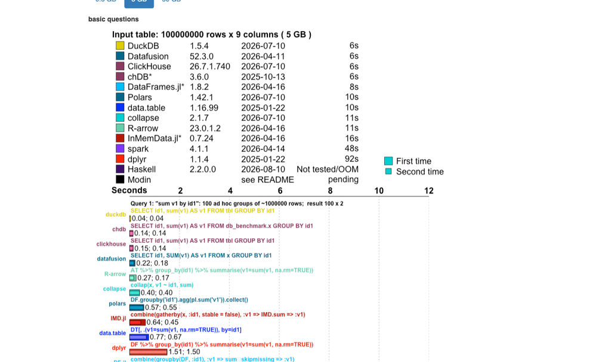

Groupby on 5 GB, 16 cores and 32 GB RAM. DuckDB is one of the winners, and Polars does a great job too. Source: [db-benchmark](https://duckdblabs.github.io/db-benchmark/)

## Why single-machine engines got so fast

### The design decisions Polars and DuckDB share

- Columnar memory (Apache Arrow): data is stored column by column, so a query reads only the columns it needs, streaming through contiguous memory
- Vectorised kernels: the heavy loops are written in Rust (Polars) or C++ (DuckDB), running in batches on your CPU’s SIMD instructions
- All cores by default: every query is parallelised across your cores, with no cluster and no `n_jobs` to set

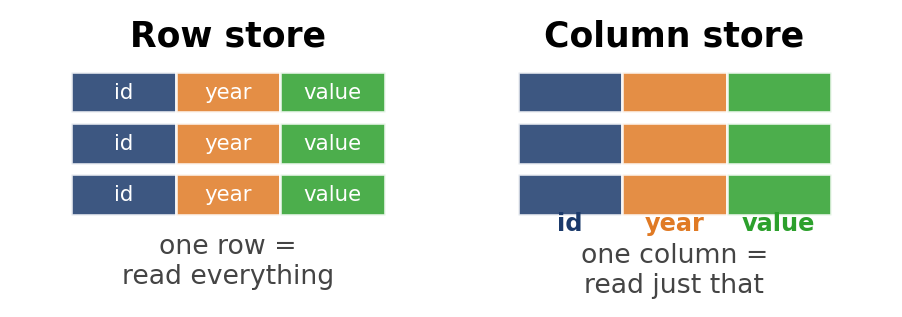

- “Average one column” then reads a tiny slice of the file

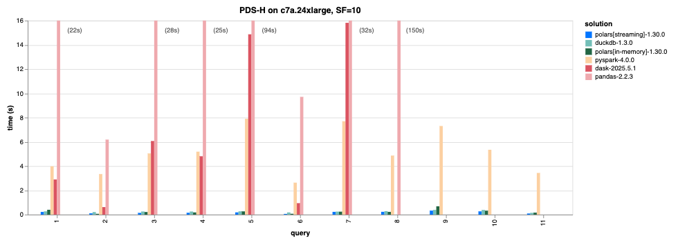

Source: [pola.rs/posts/benchmarks](https://pola.rs/posts/benchmarks/)

# Polars 🐻‍❄️

## What is Polars?

### The product page, before the syntax

- [Polars](https://pola.rs/) is a DataFrame library written in Rust
- Its own headline is “DataFrames for the new era”
- The numbers on the front page: 775 million downloads and 39,000 GitHub stars, under an MIT licence
- It feels like pandas, with four differences:
  - The multi-threaded Rust engine uses all your CPU cores automatically
  - Data sits in Arrow columnar memory
  - A lazy mode optimises your whole query before running it
  - It can stream data larger than RAM
- Install it with `pip install polars`

[figure not shown]

Source: pola.rs

## Selecting and filtering

### Expressions that pick columns and rows

- Let’s read the WDI panel you built in Module 06:

```python
import polars as pl

df = pl.read_parquet("../lecture-19/data/wdi_panel.parquet")
df.head()
```

shape: (5, 5)

| country cat | iso3 cat | indicator cat | year i16 | value f64 |
| --- | --- | --- | --- | --- |
| "Aruba" | "ABW" | "co2_per_capita" | 1990 | 3.203034 |
| "Aruba" | "ABW" | "co2_per_capita" | 1991 | 3.435717 |
| "Aruba" | "ABW" | "co2_per_capita" | 1992 | 3.634519 |
| "Aruba" | "ABW" | "co2_per_capita" | 1993 | 3.414535 |
| "Aruba" | "ABW" | "co2_per_capita" | 1994 | 3.683227 |

- Polars uses [expressions](https://docs.pola.rs/user-guide/expressions/): small descriptions of a column operation
- [`select`](https://docs.pola.rs/api/python/stable/reference/dataframe/api/polars.DataFrame.select.html) picks columns; [`filter`](https://docs.pola.rs/api/python/stable/reference/dataframe/api/polars.DataFrame.filter.html) keeps rows

```python
(
    df
    .select(["country", "year", "value"])
    .filter(pl.col("year") >= 2000)
    .head(3)
)
```

shape: (3, 3)

| country cat | year i16 | value f64 |
| --- | --- | --- |
| "Aruba" | 2000 | 2.968384 |
| "Aruba" | 2001 | 2.973567 |
| "Aruba" | 2002 | 3.225666 |

- [`read_parquet`](https://docs.pola.rs/api/python/stable/reference/api/polars.read_parquet.html) loads the whole file
- [`scan_parquet`](https://docs.pola.rs/api/python/stable/reference/api/polars.scan_parquet.html) (later) stays lazy
- The pandas equivalent of the chain on the left:

```python
# pandas
(
    df[["country", "year", "value"]]
    .loc[df["year"] >= 2000]
    .head(3)
)
```

- [`pl.col("year")`](https://docs.pola.rs/api/python/stable/reference/expressions/col.html) refers to a column inside an expression
- The round brackets around the chain make Python read the four lines as one expression
- Every method here is documented in the [Polars user guide](https://docs.pola.rs/user-guide/expressions/)

## Transforming and aggregating

### with_columns and group_by, beside their pandas equivalents

- `with_columns` adds or replaces columns

```python
(
    df.with_columns(((pl.col("year") // 10) * 10).alias("decade"))
      .select(["country", "year", "decade"])
      .head(3)
)
```

shape: (3, 3)

| country cat | year i16 | decade i16 |
| --- | --- | --- |
| "Aruba" | 1990 | 1990 |
| "Aruba" | 1991 | 1990 |
| "Aruba" | 1992 | 1990 |

- `group_by(...).agg(...)` summarises groups

```python
(
    df.group_by("indicator")
      .agg(pl.col("value").mean().alias("mean_value"),
           pl.len().alias("n"))
      .head(3)
)
```

shape: (3, 3)

| indicator cat | mean_value f64 | n u32 |
| --- | --- | --- |
| "fertility_rate" | 3.009723 | 7378 |
| "internet_users_pct" | 30.678003 | 7378 |
| "population" | 3.0805e7 | 7378 |

- The pandas equivalents:

```python
# pandas
df["decade"] = (df["year"] // 10) * 10
df[["country", "year", "decade"]].head(3)
```

```python
# pandas
df.groupby("indicator").agg(
    mean_value=("value", "mean"),
    n=("value", "size"),
).head(3)
```

- `.alias("decade")` names the new column
- Polars never mutates in place; each step returns a new frame
- Inside `.agg()` you list one expression per output column
- `pl.len()` counts rows in each group

## Lazy mode: let the engine plan the query

### Nothing runs until you call collect

- `scan_parquet` returns a lazy frame: nothing runs until you call `.collect()`
- This lets Polars reorder and prune your query like a database would

```python
lazy = (
    pl.scan_parquet("../lecture-19/data/wdi_panel.parquet")
    .filter(pl.col("year") >= 1990)
    .group_by("indicator")
    .agg(pl.col("value").mean())
)
result = lazy.collect()
result.head(3)
```

shape: (3, 2)

| indicator cat | value f64 |
| --- | --- |
| "primary_enrolment_net" | 87.585799 |
| "gdp_per_capita" | 14330.646062 |
| "urban_pop_pct" | 57.766502 |

- `.explain()` shows the optimised plan:

```python
print(lazy.explain())
```

```
AGGREGATE[maintain_order: false]
  [col("value").mean()] BY [col("indicator")]
  FROM
  simple π 2/2 ["indicator", "value"]
    Parquet SCAN [../lecture-19/data/wdi_panel.parquet]
    PROJECT 3/5 COLUMNS
    SELECTION: col("year") >= 1990
    ESTIMATED ROWS: 59024
```

- Read the nodes bottom-up: Polars pushes the filter and the column selection down into the file scan, so it never reads data it will throw away
  - It’s like `mean(filter(read(file)))`: the outermost call is written first but happens last
- `π` is projection (keep these columns) and `SELECTION` is the row filter, two ideas from [relational algebra](https://en.wikipedia.org/wiki/Relational_algebra#Projection)
- Polars reads 3 of the 5 columns and drops the old rows before any data reaches your query

## Streaming: data larger than RAM

### One argument changes how the query runs

- The same lazy query can run in streaming mode
- Polars processes the data in small batches, so the full dataset never sits in memory at once

```python
result = (
    pl.scan_parquet("../lecture-19/data/wdi_panel.parquet")
    .filter(pl.col("year") >= 1990)
    .group_by("indicator")
    .agg(pl.col("value").mean())
    .collect(engine="streaming")
)
result.shape
```

```
(8, 2)
```

- The only change is `collect(engine="streaming")`
- This is how Polars handles files bigger than your RAM on a single machine
- We use exactly this in the benchmark, on a file of 200 million rows

Note: the streaming engine has changed name across Polars versions. On Polars 1.43 (this deck) it is `collect(engine="streaming")`

## Polars and pandas can work together!

### Converting in both directions

- You do not have to choose one forever
- Convert in either direction:

```python
# Polars -> pandas
pdf = result.to_pandas()

# pandas -> Polars
back = pl.from_pandas(pdf)
type(pdf), type(back)
```

```
(pandas.DataFrame, polars.dataframe.frame.DataFrame)
```

- Typical pattern:
  - Do the heavy data work in Polars (fast, parallel)
  - Convert to pandas when a tool needs pandas: plotting with matplotlib, or feeding scikit-learn
- The conversion is cheap because both use Arrow underneath

## Try it yourself! 🧠

- Here is a pandas groupby chain on the WDI panel:

```python
import pandas as pd
df = pd.read_parquet("../lecture-19/data/wdi_panel.parquet")
out = (
    df[df["year"] >= 2000]
      .groupby("country")["value"]
      .mean()
)
```

- Your task: rewrite it in Polars lazy syntax and time both with `%timeit`
- Hint: five steps in this order, `scan_parquet` → `filter` → `group_by` → `agg` → `collect`
- `agg` takes an expression, not a column name: build it with `pl.col`, as on the lazy mode slide
- Appendix 01

# DuckDB 🦆

## SQL as a scaling tool

### The DuckDB home page, before the syntax

- [DuckDB](https://duckdb.org/) is an in-process analytical database written in C++, and its own tagline is “Your universal data wrangling tool”
- Think “SQLite for analytics”: no server, just `pip install duckdb`
- Like Polars, it is parallel and out-of-core (it can process data larger than RAM)
- Its trick: query files directly, with no loading step

[figure not shown]

Source: duckdb.org

- Query a Parquet file straight from disk:

```python
import duckdb

duckdb.sql("""
    SELECT indicator, AVG(value) AS mean_value
    FROM '../lecture-19/data/wdi_panel.parquet'
    WHERE year >= 1990
    GROUP BY indicator
    LIMIT 3
""")
```

```
┌────────────────┬────────────────────┐
│   indicator    │     mean_value     │
│    varchar     │       double       │
├────────────────┼────────────────────┤
│ urban_pop_pct  │ 57.766502068009025 │
│ co2_per_capita │   4.87445669671352 │
│ population     │ 30804601.116427217 │
└────────────────┴────────────────────┘
```

- The file path goes straight in the `FROM` clause. DuckDB reads only the columns and rows it needs

## Querying a DataFrame by name

### Your Python variable becomes a SQL table

- DuckDB can also query a DataFrame that already sits in a Python variable
- The variable name becomes the table name in your SQL

```python
import pandas as pd

pdf = pd.read_parquet(
    "../lecture-19/data/wdi_panel.parquet"
)

# The variable `pdf` is now a SQL table
duckdb.sql("SELECT COUNT(*) AS n FROM pdf")
```

```
┌───────┐
│   n   │
│ int64 │
├───────┤
│ 59024 │
└───────┘
```

- Full SQL works: `GROUP BY`, joins, subqueries, window functions
- `country` is a pandas category, which DuckDB reads as an enum: `::VARCHAR` turns it back into plain text so the result prints tidily

```python
duckdb.sql("""
    SELECT country::VARCHAR AS country,
           ROUND(AVG(value), 1) AS mean_value,
           COUNT(*) AS n
    FROM pdf
    WHERE year >= 2000
    GROUP BY country
    ORDER BY mean_value DESC
    LIMIT 3
""")
```

```
┌───────────────┬─────────────┬───────┐
│    country    │ mean_value  │   n   │
│    varchar    │   double    │ int64 │
├───────────────┼─────────────┼───────┤
│ China         │ 192742978.9 │   192 │
│ India         │ 169301998.4 │   192 │
│ United States │  42274028.5 │   192 │
└───────────────┴─────────────┴───────┘
```

## When to use SQL

### Choosing between expressions and SQL

- Polars and DuckDB solve the same problems at similar speed
- The choice is mostly about what you find readable:
  - Polars: method chains, expressions, feels like Python
  - DuckDB: SQL, familiar to anyone who took [DATASCI 151](https://danilofreire.github.io/datasci151-summer)
- Many people use both: SQL for the big aggregation, Polars or pandas for the follow-up
- A DuckDB result converts to either DataFrame with one method:
  - `.df()` gives a pandas DataFrame
  - `.pl()` gives a Polars DataFrame
- So you can write the heavy query in SQL and continue in whichever library you prefer
- The same hand-off pattern we saw with Polars

```python
q = """
    SELECT indicator, AVG(value) AS mean_value
    FROM '../lecture-19/data/wdi_panel.parquet'
    WHERE year >= 1990
    GROUP BY indicator
"""

# To pandas
pdf = duckdb.sql(q).df()

# To Polars
pol = duckdb.sql(q).pl()

type(pdf), type(pol)
```

```
(pandas.DataFrame, polars.dataframe.frame.DataFrame)
```

Want more SQL practice? The course website has a full self-study [DuckDB SQL tutorial](https://danilofreire.github.io/datasci350/04-duckdb-sql-tutorial.html). It covers `SELECT`, `WHERE`, `GROUP BY`, joins, and window functions with DuckDB, for anyone who skipped [DATASCI 151](https://danilofreire.github.io/datasci151-summer) or wants more depth

## Try it yourself! 🧠

- Take the aggregation from the last exercise (mean `value` per `country`, for `year >= 2000`)

```python
out = (
    pl.scan_parquet("../lecture-19/data/wdi_panel.parquet")
    .filter(pl.col("year") >= 2000)
    .group_by("country")
    .agg(pl.col("value").mean().alias("mean_value"))
    .collect()
)
```

- Your task: write it as a DuckDB SQL query that reads the parquet file directly, and return the result as a Polars frame
- Hint: the keywords you need, in query order, `SELECT` → `AVG` → `FROM` → `WHERE` → `GROUP BY`
- Hint: the `FROM` clause can name a file path directly, in quotes
- Hint: `.pl()` turns a DuckDB result into a Polars frame
- Appendix 02

# Let’s create a benchmark 🏁

## Our set-up

### One task to run on four engines

- One identical task and four different engines
  - mean `value` by indicator and decade, filtered to post-1990
- Our data is `wdi_big.parquet`, a synthetic panel of 200 million rows (~1.4 GB on disk)
- It is built by cloning the small WDI panel many times (script: [`data/make_big_parquet.py`](https://github.com/danilofreire/datasci350/blob/main/lectures/lecture-22/data/make_big_parquet.py))
- The file is not committed (too big); but anyone can rebuild it from the script
- Appendix 04
- Our four engines:

| Engine | Strategy |
| --- | --- |
| pandas | load all, then `groupby` |
| Polars | lazy scan + streaming |
| DuckDB | SQL over the file |
| Dask | parallel DataFrame + dashboard |

- The numbers on the next slides were measured once on my machine and saved to [`data/benchmark_results.csv`](https://raw.githubusercontent.com/danilofreire/datasci350/main/lectures/lecture-22/data/benchmark_results.csv)
- The deck reads that CSV. It doesn’t re-run the benchmark

## The four queries, side by side

### Polars and DuckDB here; pandas and Dask in Appendix 05

Polars (lazy + streaming):

```python
import polars as pl
(pl.scan_parquet("data/wdi_big.parquet")
   .filter(pl.col("year") >= 1990)
   .with_columns(((pl.col("year") // 10) * 10).alias("decade"))
   .group_by("indicator", "decade")
   .agg(pl.col("value").mean())
   .collect(engine="streaming"))
```

DuckDB (SQL over the file):

```python
import duckdb
duckdb.sql("""
    SELECT indicator, (year // 10) * 10 AS decade,
           AVG(value) AS mean_value
    FROM 'data/wdi_big.parquet'
    WHERE year >= 1990
    GROUP BY indicator, decade
""").df()
```

- The same query in SQL, with the file path in the `FROM` clause
- The pandas and Dask versions of this query are in Appendix 05

## The results

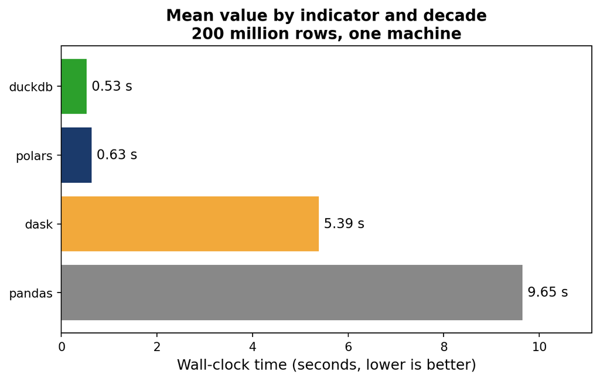

- Polars and DuckDB finish in well under a second
- pandas is over 15× slower, and must hold the whole column set in RAM
- Dask beats pandas by parallelising and streaming, but the single-machine engines still win here
- Macbook Pro, Apple M5, 10 cores, 24 GB RAM

## Reading the benchmark honestly

- Every benchmark measures one task on one machine
- Treat the numbers as evidence about this setting, and expect them to shift with:
  - the task (this one is a simple aggregation)
  - the hardware (cores, RAM, disk speed)
  - the data shape and file layout
- What stays the same:
  - The order of magnitude: Polars and DuckDB are far ahead for single-node analytics
  - The zero setup cost: no cluster, no config
- The order of magnitude is the result worth remembering; the exact seconds will differ on your machine

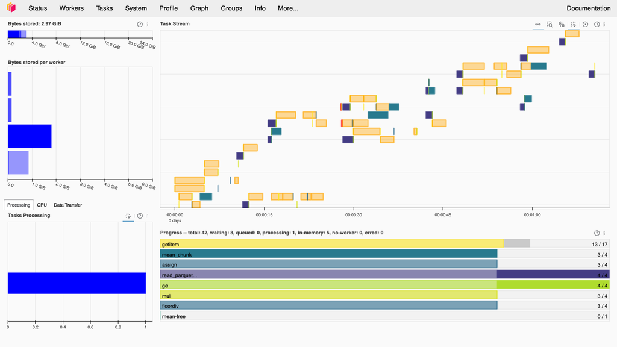

The Dask task stream during the benchmark

# Which tool when? 🧭

## A decision framework

### What we have been building

| Your situation | Reach for |
| --- | --- |
| Fits in RAM, quick exploration, plotting | pandas |
| Big single file or many files, one machine | Polars or DuckDB (expressions or SQL, your preference) |
| Bigger than the machine, a real cluster, or task graphs / arrays | Dask (or Spark in industry) |

`pandas → Polars/DuckDB → Dask`

- When Dask still wins:
  - Data larger than one machine’s disk
  - A real cluster of many machines
  - Parallel arrays and custom task graphs (the `dask.delayed` pipelines from last lecture)
- Fast single-machine engines shrink the set of problems that need Dask. The cases above remain genuinely distributed
- pandas is still the right default for small data and for the huge ecosystem around it
- Polars and DuckDB answer “my data got big and still fits on one machine”
- From last lecture, before you scale anything:
  - Amdahl first: measure where the time goes
  - A better algorithm or a faster engine often beats adding cores

## A word on GPUs

### When different hardware is worth the trouble

- Everything today used your CPU, which are general-purpose processors with a few fast cores
- A [GPU](https://developer.nvidia.com/cuda-zone) has thousands of small, slow cores
- That suits data-parallel work
  - The same operation applied to millions of numbers at once, like matrix multiplication
- This is exactly what training a neural network needs
- GPUs pay off when the work is the same arithmetic repeated across millions of values
- Ordinary data wrangling rarely has that shape, which is why everything else today ran on the CPU
- For data analysis, the GPU stack is [RAPIDS, renamed CUDA-X in August 2026](https://developer.nvidia.com/topics/ai/data-science/cuda-x-for-data-science):
  - [cuDF](https://docs.rapids.ai/api/cudf/stable/): DataFrames on the GPU
  - [cuML](https://docs.rapids.ai/api/cuml/stable/): the same offer for scikit-learn

[figure not shown]

Source: [NVIDIA CUDA-X](https://developer.nvidia.com/topics/ai/data-science/cuda-x-for-data-science)

## GPUs without rewriting your code

- [cudf.pandas](https://docs.rapids.ai/api/cudf/stable/cudf_pandas/) accelerates pandas from one line
  - `%load_ext cudf.pandas` in a notebook
- It covers the whole pandas API and falls back to the CPU, so your code still runs
- The [Polars GPU engine](https://docs.rapids.ai/api/cudf/stable/cudf_polars/) does the same for lazy Polars
  - You pass an engine to `collect`, and unsupported queries fall back to the CPU
- It is still open beta, and NVIDIA aims it at datasets of hundreds of gigabytes and up
- No GPU on your laptop? [Google Colab](https://colab.research.google.com/) gives you one for free, and both projects ship a Colab demo
- Nothing in the final project needs a GPU

[figure not shown]

# Conclusion

## Summary

### What we learned today

- We set up a Dask cluster and watched work flow through the dashboard
- We saw why the new engines are fast
  - They store data by column, and their compiled kernels use every core without any configuration
- Polars: expressions, lazy mode, streaming, pandas interop
- DuckDB: SQL over files, out-of-core, results to pandas or Polars
- The benchmark: on 200 million rows, Polars and DuckDB finished in under a second, an order of magnitude ahead of pandas and Dask
- A decision framework: pandas for small data, Polars or DuckDB on one machine, Dask when you outgrow it
- Measure where the time goes before you scale anything

## Next class

- Lecture 23 moves from making your pipeline fast to making it run anywhere
- The tools: containers and dependency management
- Today your code depended on your Python, your versions, and your laptop
- Next class we package all three
- A classmate, a server, or a marker then gets the same result
- The `pip install` lines from this deck stop being setup instructions, and become part of an image you build

Before then:

1. Finish both exercises if you did not complete them in class
2. Time the four engines on the small panel, using the code in Appendix 05
3. Check that `dask`, `polars`, and `duckdb` all import in your environment
- Quiz 04 covers web APIs and JSON (Module 06)
- Your final project pulls World Bank data from the API
- It processes that data with the tools from this module, and ships it in a container

# Thank you! 🚀

# Appendix 📚

## Appendix 01: Solution to Exercise 01

- Rewrite the pandas chain in Polars lazy syntax:

```python
import polars as pl

out = (
    pl.scan_parquet("../lecture-19/data/wdi_panel.parquet")
    .filter(pl.col("year") >= 2000)
    .group_by("country")
    .agg(pl.col("value").mean().alias("mean_value"))
    .collect()
)
out.head(3)
```

shape: (3, 2)

| country cat | mean_value f64 |
| --- | --- |
| "Armenia" | 406031.651588 |
| "Ukraine" | 6.1044e6 |
| "St. Vincent and the Grenadines" | 15106.342198 |

- The three verbs, in order: `filter` (keep recent rows), `group_by` (form the groups), `agg` (summarise)
- On this small panel, both pandas and Polars finish in milliseconds. The gap only appears on large data

Back to exercise

## Appendix 02: Solution to Exercise 02

- The same aggregation in DuckDB SQL, returned as a Polars frame:

```python
import duckdb

result = duckdb.sql("""
    SELECT country, AVG(value) AS mean_value
    FROM '../lecture-19/data/wdi_panel.parquet'
    WHERE year >= 2000
    GROUP BY country
""").pl()

result.head(3)
```

shape: (3, 2)

| country str | mean_value f64 |
| --- | --- |
| "Burundi" | 1.3053e6 |
| "Brazil" | 2.5584e7 |
| "Cuba" | 1.4414e6 |

- The file path sits directly in the `FROM` clause
- `.pl()` turns the DuckDB result into a Polars frame (use `.df()` for pandas)

Back to exercise

## Appendix 03: When something goes wrong

`No buffer space available`

The cluster ran out of network resources for worker-to-worker traffic. Use a smaller array, or lower `n_workers` and `threads_per_worker`.

`Stream is closed` or `CommClosedError`

A worker died mid-computation, usually in an interactive terminal. Run the same code from a script or a Jupyter notebook instead.

The dashboard will not open

The port is already taken. Pick a free one with `dashboard_address=':8789'`, or let Dask choose automatically.

Workers keep restarting

This is memory pressure. Lower `n_workers`, raise the memory limit, or process the data in smaller chunks.

The computation hangs

You probably created two clients. Restart the kernel and create exactly one `Client`

General advice: create one `Client` at the top of your script and reuse it. Watch the task stream and worker memory panels on the dashboard, and when in doubt restart the client and run on a smaller sample first

Back to the client

## Appendix 04: Rebuilding the big file

- `wdi_big.parquet` is not committed to the repository (it is ~1.4 GB)
- Rebuild it from the small panel with the [generation script](https://github.com/danilofreire/datasci350/blob/main/lectures/lecture-22/data/make_big_parquet.py):

```
cd lectures/lecture-22/data
python make_big_parquet.py
```

- Default: ~200 million rows. For a slower laptop, use fewer replicas:

```
python make_big_parquet.py --replicas 400
```

- The script uses a fixed seed, so everyone who runs it gets the same file
- This is the Module 06 principle: do not commit data you can regenerate from a script

Back to the benchmark

## Appendix 05: The pandas and Dask queries

pandas (loads everything into memory):

```python
import pandas as pd
df = pd.read_parquet("data/wdi_big.parquet",
                     columns=["indicator", "year", "value"])
df = df[df["year"] >= 1990]
df["decade"] = (df["year"] // 10) * 10
df.groupby(["indicator", "decade"])["value"].mean()
```

- The whole three-column slice has to fit in RAM before the `groupby` starts

Dask (parallel DataFrame):

```python
import dask.dataframe as dd
df = dd.read_parquet("data/wdi_big.parquet",
                     columns=["indicator", "year", "value"])
df = df[df["year"] >= 1990]
df["decade"] = (df["year"] // 10) * 10
df.groupby(["indicator", "decade"])["value"].mean().compute()
```

- The pandas code with two changes: `dd` in place of `pd`, and a `.compute()` at the end

Back to the queries